# Antibiotic analysis of Nat Med paper

Diana Proctor

07/14/2025

Let’s get the antibiotic, antiviral, steroid and antifungal data coded up in a way that we can analyze their impact on the nursing home microbiome

```r
#set global knitting options
knitr::opts_chunk$set(echo = TRUE, warning = FALSE, message = FALSE, error = FALSE, fig.width = 12, fig.height = 5)
```

Define functions and color palettes

Read in the amplicon data

```r
bac_match = readRDS("~/OneDrive\ -\ UTHealth\ Houston/Expansion-2024/NIH-2024/Desktop/Nature_Medicine/data/phyloseq/merged_16s_bac_match_cauris_clinical_map_withsqrt_withtree_withcoo_2020-03-19.rds") %>%
  subset_samples(., Survey_Period==1)

map = data.frame(sample_data(bac_match)) %>%
  dplyr::select(., c("site","Unique_ptid", "LibraryID", "chg_conc", "CFUTotal_Cauris","CFUTransform_Cauris", "Cauris_Result",
                     "Site.Extended", "SiteID", "mech_vent",  "trach", "gtube", "ostomy", "fecal_device", "urinary_cath",
                     "Fungal.Matcher",           "caurisReads",              "percentAuris"            )) %>%
  sample_data(.)
sample_data(bac_match) = map

sites =  read.csv("~/OneDrive\ -\ UTHealth\ Houston/Expansion-2024/NIH-2024/Desktop/Nature_Medicine/data/metadata/sitecode_to_factored_sites.csv")
full.dat = readxl::read_excel("~/OneDrive\ -\ UTHealth\ Houston/Expansion-2024/NIH-2024/Desktop/Nature_Medicine/data/metadata/Cauris_Medications_2020-07-23.xlsx") %>%
  subset(., DrugClass %in% c("ANTIBIOTICS", "ANTIFUNGALS", "STEROIDS", "ANTIVIRALS"))
```

we need to clean up the antibiotic, antiviral, steroid and antifungal data - determine how many days before each sample period these were taken - standardize the names of the meds to a code that can be inter operable

```r
# Make sure your dates are Date type
full.dat$Survey1_CollectDate <- as.Date(full.dat$Survey1_CollectDate)
full.dat$StartDate <- as.Date(full.dat$StartDate)

# Create a new column: days between StartDate and Survey 1, 2, 3
full.dat$Days_Before_Survey1 <- as.numeric(difftime(full.dat$Survey1_CollectDate, full.dat$StartDate, units = "days"))
full.dat$Days_Before_Survey2 <- as.numeric(difftime(full.dat$Survey2_CollectDate, full.dat$StartDate, units = "days"))
full.dat$Days_Before_Survey3 <- as.numeric(difftime(full.dat$Survey3_CollectDate, full.dat$StartDate, units = "days"))
```

ATCodeR package - we get standard codes for 31 drugs but not all 54 unique drugs

```r
# Load ATCodeR package and standardize the drug names
library(ATCodeR)
library(dplyr)

input_test = data.frame(input_med = full.dat$MedName) %>%
  distinct(.) #54
test_df <- ATCtransform(input.df = input_test, column_name = "input_med") #31 drugs were processed

# Assuming your dataframe is called test_df
#unassigned_drugs <- test_df %>%
 # filter(
 #   AdditionalMedication == "" &
 #   Medication == "" &
#    Info == ""
  #) %>%
#  dplyr::select(input_med)

unassigned_drugs
```

let’s try another method suggested by chatGPT whichaccesses the RxNorm package using a direct HTTP request (using the httr package) to the RxNorm REST API provided by the National Library of Medicine (NLM).4

```r
library(httr)
library(jsonlite)
library(purrr)
library(dplyr)
library(stringr)

test_df <- data.frame(input_med = full.dat$MedName) %>%
  distinct()

# Enhanced cleaning function
clean_name <- function(name) {
  name %>%
    tolower() %>%
    # Remove common salts and modifiers, both whole phrases and parts
    gsub("\\b(sodium succinate|sod succinate|sod succ|sodium succ|nitrate|acetate|succinate|ace|sod|pot clavulanate|potassium clavulanate|chloride)\\b", "", ., ignore.case = TRUE) %>%
    # Remove dosage forms and administration routes
    gsub("\\b(tablet|cream|ointment|%|patch|capsule|solution|syrup|injection|suspension|powder|oral|dextrose|sensimist|remedy|spray|gel|lotion|cream|eye drop|eye drops|cream)\\b", "", ., ignore.case = TRUE) %>%
    # Remove strength or dosage numbers (e.g. 0.5, 10 mg)
    gsub("\\b\\d+(\\.\\d+)?\\b", "", .) %>%
    # Replace dots, dashes, slashes with spaces
    gsub("[./-]", " ", .) %>%
    # Remove any leftover punctuation
    gsub("[[:punct:]]", "", .) %>%
    # Remove extra spaces
    str_squish() %>%
    # Trim spaces
    trimws()
}

# Apply cleaning
drug_names <- test_df$input_med
cleaned_names <- sapply(drug_names, clean_name)

# Function to get RxCUI (same as before)
get_rxcui <- function(drug_name) {
  if (is.na(drug_name) || drug_name == "") return(NA)
  url <- paste0("https://rxnav.nlm.nih.gov/REST/rxcui.json?name=", URLencode(drug_name))
  res <- httr::GET(url)
  if (res$status_code == 200) {
    content <- fromJSON(httr::content(res, "text", encoding = "UTF-8"))
    if (!is.null(content$idGroup$rxnormId)) {
      return(content$idGroup$rxnormId[[1]])
    }
  }
  return(NA)
}

# Get unique cleaned names to avoid repeated queries
unique_cleaned <- unique(cleaned_names)

# Map to RxCUI once per unique name
rxcui_map <- map_chr(unique_cleaned, get_rxcui)

# Create lookup table
lookup <- data.frame(cleaned_drug = unique_cleaned, rxcui = rxcui_map, stringsAsFactors = FALSE)

# Join back to full data
results <- data.frame(original_drug = drug_names, cleaned_drug = cleaned_names, stringsAsFactors = FALSE) %>%
  left_join(lookup, by = "cleaned_drug")

# Summary
unmatched_count <- sum(is.na(results$rxcui))
cat("Unmatched drugs:", unmatched_count, "\n")
```

```
## Unmatched drugs: 7
```

```r
failed_drugs <- results %>% filter(is.na(rxcui))

# Add delimiter for manual checking if needed
failed_drugs$cleaned_drug_delim <- str_replace_all(failed_drugs$cleaned_drug, " ", " / ")
print(failed_drugs)
```

```
##                      original_drug                  cleaned_drug rxcui
## 1  Sulfamethoxazole - Trimethoprim sulfamethoxazole trimethoprim  <NA>
## 2          Piperacillin-Tazobactam       piperacillin tazobactam  <NA>
## 3             Ampicillin-Sulbactam          ampicillin sulbactam  <NA>
## 4                 Antifungal Cream                    antifungal  <NA>
## 5    Neomycin/polymixin/bacitracin neomycin polymixin bacitracin  <NA>
## 6          Remedy Antifungal Cream                    antifungal  <NA>
## 7 Piperacillin-Tazobactam-Dextrose       piperacillin tazobactam  <NA>
##                  cleaned_drug_delim
## 1   sulfamethoxazole / trimethoprim
## 2         piperacillin / tazobactam
## 3            ampicillin / sulbactam
## 4                        antifungal
## 5 neomycin / polymixin / bacitracin
## 6                        antifungal
## 7         piperacillin / tazobactam
```

get the multiple ingredient drugs (MIN) RxCui codes - programmatically my efforts failed - i manually got the multiple component drugs and now we only have 3 lines that aren’t annotated, 1 drug for which we will use the name since it’s a penicillin and 2 that are to generall too nail down

```r
url <- "https://rxnav.nlm.nih.gov/REST/approximateTerm.json?term=amoxicillin%20pot%20clavulanate"
res <- httr::GET(url)
content <- fromJSON(httr::content(res, "text", encoding = "UTF-8"))

str(content$approximateGroup)
```

```
## List of 2
##  $ inputTerm: NULL
##  $ candidate:'data.frame':   20 obs. of  6 variables:
##   ..$ rxcui : chr [1:20] "19711" "19711" "19711" "1152875" ...
##   ..$ rxaui : chr [1:20] "12353525" "2626717" "392488" "12287098" ...
##   ..$ score : chr [1:20] "15.686198234558105" "15.686198234558105" "15.686198234558105" "15.052496910095215" ...
##   ..$ rank  : chr [1:20] "1" "1" "1" "4" ...
##   ..$ name  : chr [1:20] "amoxicillin / clavulanate" "AMOXICILLIN/CLAVULANATE" NA "amoxicillin / clavulanate Pill" ...
##   ..$ source: chr [1:20] "RXNORM" "VANDF" "MMSL" "RXNORM" ...
```

```r
# Check if candidate exists and what it contains
if (!is.null(content$approximateGroup$candidate)) {
  print(content$approximateGroup$candidate)
} else {
  print("No candidates found")
}
```

```
##      rxcui    rxaui              score rank
## 1    19711 12353525 15.686198234558105    1
## 2    19711  2626717 15.686198234558105    1
## 3    19711   392488 15.686198234558105    1
## 4  1152875 12287098 15.052496910095215    4
## 5   831418 10280966 14.534214973449707    5
## 6   831418 10328394 14.534214973449707    5
## 7   831418  2940700 14.534214973449707    5
## 8   831418  3869885 14.534214973449707    5
## 9   831418   527750 14.534214973449707    5
## 10  831418   527752 14.534214973449707    5
## 11  562250 12256845   14.4977199716568   11
## 12  562252 12256846   14.4977199716568   11
## 13  617292 12263446   14.4977199716568   11
## 14  617294 12263448   14.4977199716568   11
```

[output cut: 27 more lines]

```r
#i googled these codes and got them manually on July 14, 2025
# Your manual lookup as a data.frame
manual_rxcui_df <- data.frame(
  MedName = c(
    "Sulfamethoxazole - Trimethoprim",
    "Piperacillin-Tazobactam",
    "Ampicillin-Sulbactam",
    "Neomycin/polymixin/bacitracin",
    "Piperacillin-Tazobactam-Dextrose",
    "Amoxicillin-Pot Clavulanate"
  ),
  manual_rxcui = c("10831", "74169", "1009148", "C5835035", "74169", "Amoxicillin-Pot Clavulanate"),
  stringsAsFactors = FALSE
)
results$MedName = results$original_drug
results_updated <- results %>%
  left_join(manual_rxcui_df, by = "MedName") %>%
  mutate(rxcui = if_else(is.na(rxcui), manual_rxcui, rxcui)) %>%  # fill NAs
  dplyr::select(-manual_rxcui)  # remove helper column


# List drugs that still failed
failed_drugs <- results_updated %>% filter(is.na(rxcui))
```

merge with the original data4

- Amoxicillin-Pot Clavulanate is the only drug i can’t seem to get right

```r
colnames(results)[1] = "MedName"

mydf = plyr::join(results_updated, full.dat)
failed_drugs <- mydf %>% filter(is.na(rxcui))
```

now let’s convert our cleaned drug names into a binary variable

```r
# Ensure mydf is a data.table
data.table::setDT(mydf)

# Keep only Unique_ptid, cleaned_drug, and create presence = 1
mydf_small <- mydf[, .(Unique_ptid, cleaned_drug)]
mydf_small[, present := 1]

# dcast to wide format with one row per Unique_ptid
wide_df <- dcast(mydf_small, Unique_ptid ~ cleaned_drug, value.var = "present", fill = 0, fun.aggregate = max)

#merge with sample map
map = data.frame(sample_data(bac_match))
Freq = data.frame(table(map$Unique_ptid, map$Cauris_Result))
colnames(Freq) = c("Unique_ptid", "Cauris_Result", "N.Colonized.Sites")


#let's see how many samples per person
NSamples = data.frame(table(map$Unique_ptid))
colnames(NSamples) = c("Unique_ptid",  "N.Samples")
annotations = plyr::join(Freq, NSamples)

#let's calculate the candida index which is the numer of colonized sites / number of sites
annotations$Candida_index = round(annotations$N.Colonized.Sites/annotations$N.Samples, 2)
df = plyr::join(wide_df, annotations)

#update the map
map$Cauris_Result = NULL
new.map <- merge(df, map) %>%
  filter(complete.cases(SiteID)) %>%
  distinct(Fungal.Matcher, .keep_all = TRUE) %>%
  column_to_rownames("Fungal.Matcher") %>%
  sample_data()


sample_data(bac_match) = sample_data(new.map)
```

```r
library(lme4)
library(reshape2) # for colsplit

# Fix column names with dots replacing spaces (if needed)
abx_vars <- stringr::str_replace_all(colnames(new.map)[7:42], " ", ".")

# Recover Subject and Site from rownames (assuming rownames like "Subject;Site")
foo <- colsplit(rownames(new.map), pattern = ";", names = c("Unique_ptid", "site"))

# Assign recovered columns back to new.map (make sure new.map is a data.frame)
new.map <- data.frame(new.map)
new.map$Unique_ptid <- foo$Unique_ptid
new.map$site <- foo$site  # overwriting existing site column if needed

# Build formula string without Survey_Period
fixed_effects <- paste(c(abx_vars, "site"), collapse = " + ")
formula_str <- paste("Candida_index ~", fixed_effects, "+ (1 | Unique_ptid)")

# Convert to formula object
model_formula <- as.formula(formula_str)

# Fit linear mixed effects model
lmer_model <- lmer(model_formula, data = new.map)

# Check model summary
summary(lmer_model)
```

```
## Linear mixed model fit by REML ['lmerMod']
## Formula: Candida_index ~ azithromycin + aztreonam + bacitracin + budesonide +
##     cefdinir + cefepime + ceftazidime + ceftriaxone + cephalexin +
##     ciprofloxacin + clarithromycin + colistimethate.sodium +
##     colistin + doxycycline + ertapenem + flonase + fluconazole +
##     fludrocortisone + hydrocortisone + levofloxacin + linezolid +
##     meropenem + metronidazole + micafungin + miconazole + mupirocin +
##     neomycin.polymixin.bacitracin + nystatin + piperacillin.tazobactam +
##     prednisolone + prednisone + sulfamethoxazole.trimethoprim +
##     tigecycline + tobramycin + triamcinolone.acetonide + vancomycin +
##     site + (1 | Unique_ptid)
##    Data: new.map
##
## REML criterion at convergence: -8131
##
## Scaled residuals:
##        Min         1Q     Median         3Q        Max
## -1.151e-06 -4.756e-08  8.160e-09  8.569e-08  2.815e-07
##
## Random effects:
##  Groups      Name        Variance  Std.Dev.
##  Unique_ptid (Intercept) 3.957e-03 6.291e-02
##  Residual                7.403e-16 2.721e-08
## Number of obs: 304, groups:  Unique_ptid, 38
##
## Fixed effects:
##                                 Estimate Std. Error t value
## (Intercept)                    3.883e-01  4.723e-02   8.220
## azithromycin                  -2.169e-01  8.287e-02  -2.618
## aztreonam                     -7.963e-01  1.322e-01  -6.026
## bacitracin                     1.159e-01  4.779e-02   2.426
## cefdinir                      -1.064e+00  1.510e-01  -7.044
## cefepime                      -2.632e-01  5.123e-02  -5.137
## ceftazidime                   -2.783e-02  9.868e-02  -0.282
## ceftriaxone                    1.160e-01  1.008e-01   1.152
## cephalexin                    -3.713e-01  1.057e-01  -3.513
## ciprofloxacin                  4.937e-01  6.050e-02   8.161
## clarithromycin                -8.616e-01  1.451e-01  -5.936
## colistimethate.sodium          1.737e-01  1.159e-01   1.499
## colistin                      -4.955e-01  1.453e-01  -3.409
```

[output cut: 8 more lines]

```
## mupirocin                     -3.580e-01  6.533e-02  -5.480
## nystatin                       4.903e-02  4.249e-02   1.154
## piperacillin.tazobactam        3.435e-01  5.932e-02   5.792
## sulfamethoxazole.trimethoprim -2.476e-01  4.654e-02  -5.320
## triamcinolone.acetonide        2.510e-01  5.801e-02   4.327
## vancomycin                     3.928e-01  5.454e-02   7.203
## siteSite_Ax;Survey_1          -2.396e-15  7.442e-09   0.000
## siteSite_Bu/To;Survey_1       -1.736e-15  8.127e-09   0.000
## siteSite_Ea;Survey_1          -1.745e-15  7.531e-09   0.000
## siteSite_Fg;Survey_1          -2.377e-15  7.151e-09   0.000
## siteSite_Ic;Survey_1          -1.114e-15  7.421e-09   0.000
## siteSite_N;Survey_1           -1.381e-15  7.285e-09   0.000
## siteSite_Ne;Survey_1          -1.466e-15  7.247e-09   0.000
## siteSite_Tc;Survey_1          -6.687e-16  7.893e-09   0.000
## siteSite_Tw;Survey_1          -1.260e-15  7.279e-09   0.000
```

```
## fit warnings:
## fixed-effect model matrix is rank deficient so dropping 10 columns / coefficients
## optimizer (nloptwrap) convergence code: 0 (OK)
## Model failed to converge with max|grad| = 0.532539 (tol = 0.002, component 1)
## Model is nearly unidentifiable: very large eigenvalue
##  - Rescale variables?
```

let’s look for correlation among antibiotics

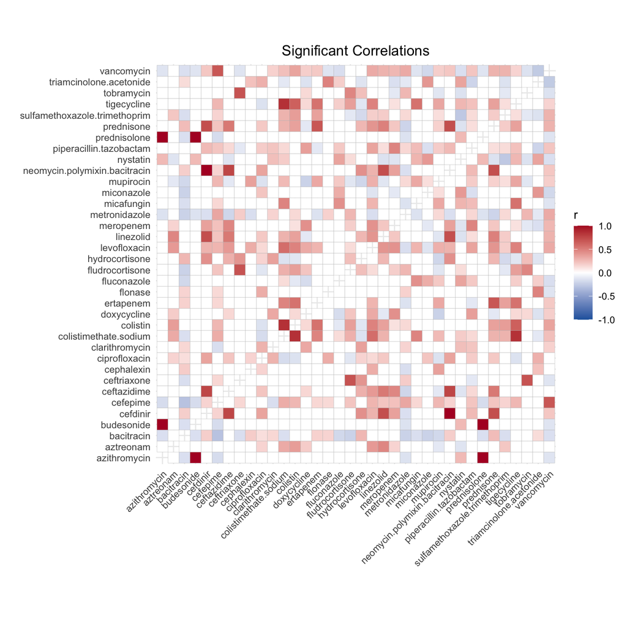

```r
# Load necessary libraries
library(Hmisc)
library(ggcorrplot)
library(corrplot)
# Compute correlation matrix with significance values
res <- rcorr(as.matrix(new.map[, abx_vars]), type = "pearson")

# Extract correlation and p-value matrices
cor_mat <- res$r
p_mat <- res$P

# Plot only significant correlations (e.g., p < 0.05)
library(Hmisc)
library(corrplot)

# Compute correlation and p-values
res <- rcorr(as.matrix(new.map[, abx_vars]), type = "pearson")
cor_mat <- res$r
p_mat <- res$P

# Enhanced visualization
ggcorrplot(
  cor_mat,
  method = "square",         # or "circle"
  type = "full",            # upper triangle only
  p.mat = p_mat,             # p-value matrix
  sig.level = 0.05,          # threshold for significance
  insig = "blank",           # hide insignificant values
  colors = c("#2166AC", "white", "#B2182B"),  # diverging palette
  title = "Significant Correlations",
  legend.title = "r",
  show.diag = FALSE
) +
  theme_minimal() +
  theme(
    axis.text.x = element_text(angle = 45, vjust = 1, hjust = 1),
    plot.title = element_text(hjust = 0.5)
  ) + ylab("") + xlab("")
```

effect of antibiotics on the microbiome - permanova

```r
# Compute distance matrix
dist_mat <- phyloseq::distance(merged_physeq, method = "bray")

# Sample metadata
meta <- data.frame(sample_data(merged_physeq))

# Choose a site to subset if needed
# site_meta <- meta[meta$SiteID == "Ne", ]
# dist_mat <- as.dist(as.matrix(dist_mat)[rownames(site_meta), rownames(site_meta)])

# Build a formula including all antibiotics
abx_vars <- colnames(meta)[3:ncol(meta)]
formula_str <- paste("dist_mat ~", paste(abx_vars, collapse = " + "))

# Run PERMANOVA
adonis_result <- adonis2(as.formula(formula_str), data = meta, by="terms")
adonis_result


#let's see if the antibiotics are the predictor of c.a uris colonization
```

[output not shown]